```r
library(effects)
library(emmeans)
library(ggpubr)
library(lme4)
library(skimr)
library(stringr)
library(tidyverse)
```

# From MTEB to MTOB: Retrieval-Augmented Classification for Descriptive Grammars

Данные взяты из исследования (Kornilov & Shavrina, 2024): [From MTEB to MTOB: Retrieval-Augmented Classification for Descriptive Grammars](https://arxiv.org/pdf/2411.15577).

Источник данных: репозиторий [from-MTEB-to-MTOB](https://github.com/al-the-eigenvalue/from-MTEB-to-MTOB/tree/main).

Статья (Kornilov & Shavrina, 2024) исследует способность больших языковых моделей (LLM) извлекать данные о языках мира из их описательных грамматик. Один из бенчмарков, представленных в статье, состоит из 148 грамматик, для каждой из которых размечены следующие типологические характеристики:

1. Доминантный порядок слов в монотранзитивной конструкции (WALS 81A – Order of Subject, Object, and Verb. SOV/SVO/VSO и т.д.)
2. Стратегия маркирования стандартного отрицания (GB107 – “Can standard negation be marked by an affix, clitic or modification of the verb?”). 1 = отрицание может маркироваться любой модификацией глагола, 0 = не может
3. Cтратегии маркирования полярных вопросов (GB257, GB260, GB262, GB263, GB264, GB286, GB291: Interrogative intonation only, Interrogative word order, Clause-initial question particle, Clause-medial question particle, Clause-final question particle, Interrogative verb morphology, Tone). 7 бинарных признаков. Для каждого признака/стратегии 1, если она может использоваться для маркирования полярных вопросов, и 0, если не может.

В работе тестируется GPT-4o в четырёх конфигурациях Retrieval Augmented Generation (RAG):

± Ранжирование контекста (реранкер)

± Метод цепочки рассуждений (Chain-of-Thought, CoT)

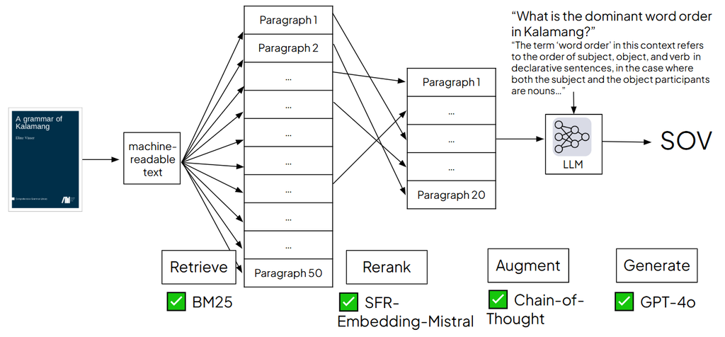

## Цель проекта:

Выявить статистически значимые факторы, влияющие на точность (accuracy) предсказаний GPT-4o для характеристик 1–3 (точность = правильная vs. неправильная классификация).

Для каждого фактора (макроареал, кол-во страниц в грамматике, год публикации, конфигурация RAG-системы):

H0: фактор не имеет связи с качеством предсказаний GPT-4o;

H1: фактор имеет связь с качеством предсказаний GPT-4o.

Уровень значимости, который мы будем использовать: 0.05.

## Гипотезы и обоснование их проверки

Исследуем зависимость accuracy от следующих переменных:

**1. Конфигурация RAG**

Почему? - Это основная экспериментальная переменная. Проверяем, повышают ли реранкинг и Chain-of-Thought (опциональные элементы в конфигурации) качество системы.

**2. Объём грамматики (кол-во страниц)**

Почему? - Есть гипотеза, что длина документа влияет на эффективность поиска. Мало страниц → ключевые детали могут быть опущены или описаны слишком кратко. Много страниц → релевантная информация может “потеряться” в большом объёме текста (“иголка в стоге сена”), что затруднит её извлечение RAG-модулем.

**3. Год издания грамматики**

Почему? - Лингвистическая терминология и стиль описания меняются со временем. В грамматиках XX века могут использоваться иные термины, чем в современных.

**4. Макроареал языка**

Почему? - Из-за разных лингвистических традиций описания языков разных регионов также могут варьироваться термины и способ описания лингвистических феноменов.

Пример вариативности: в разных грамматиках порядок слов Subject-Object-Verb может быть описан как

- Subject-Object-Verb
- SOV
- S-O-V
- AOV
- A-O-V
- head-final
- predicate-final
- verb-final

## Датасет

```r
grammars <- read.csv("https://raw.githubusercontent.com/al-the-eigenvalue/from-MTEB-to-MTOB/refs/heads/main/ground_truth_rag.csv")
glimpse(grammars)
```

```
## Rows: 148
## Columns: 21
## $ ISO.639.3            <chr> "spp", "djm", "mhi", "dba", "guk", "khq", "sif", …
## $ Language             <chr> "Supyire", "Jamsay", "Ma'di", "Bangime", "Gumuz",…
## $ Filename             <chr> "carlson1994grammar", "heath2008grammar", "blacki…
## $ WALS.116A            <chr> "Clause-initial question particle", "Clause-final…
## $ WALS.116A..Pages     <chr> "527-529", "460-463", "25, 425, 631-632", "437", …
## $ WALS.116A..PDF.Pages <chr> "550-552", "482-485", "41, 443, 649-650", "457", …
## $ GB.107               <int> 1, 1, 0, 1, 1, 0, 0, 1, 1, 0, 1, 1, 1, 0, 1, 1, 1…
## $ GB.107..Pages        <chr> "376-397", "11, 366-371", "20-21, 466-474", "314-…
## $ GB.107..PDF.Pages    <chr> "399-420", "33, 388-393", "36-37, 484-492", "334-…
## $ WALS.81A             <chr> "SOV", "SOV", "No dominant order", "No dominant o…
## $ WALS.81A..Pages      <chr> "238", "17", "15", "257", "409", "11", "11", "209…
## $ WALS.81A..PDF.Pages  <chr> "261", "39", "31", "277", "438", "27", "33", "230…
## $ Title                <chr> "A Grammar of Supyire", "A grammar of Jamsay", "A…
## $ Family               <chr> "Niger-Congo", "Dogon", "Central Sudanic", "Bangi…
## $ Subfamily            <chr> "", "", "", "", "", "", "", "", "", "", "", "Benu…
## $ Genus                <chr> "Senufo", "Dogon", "Moru-Ma'di", "Bangime", "Gumu…
## $ Macroarea            <chr> "Africa", "Africa", "Africa", "Africa", "Africa",…
## $ Author               <chr> "Carlson, Robert", "Heath, Jeffrey", "Blackings, …
## $ Year                 <chr> "1990", "2008", "2003", "2013", "2012", "1999", "…
## $ Pages                <int> 1048, 755, 750, 550, 506, 467, 432, 344, 342, 289…
## $ Type                 <chr> "grammar", "grammar", "grammar", "grammar", "gram…
```

```r
skim(grammars)
```

Data summary

| Name | grammars |
| --- | --- |
| Number of rows | 148 |
| Number of columns | 21 |
| _______________________ |  |
| Column type frequency: |  |
| character | 19 |
| numeric | 2 |
| ________________________ |  |
| Group variables | None |

**Variable type: character**

| skim_variable | n_missing | complete_rate | min | max | empty | n_unique | whitespace |
| --- | --- | --- | --- | --- | --- | --- | --- |
| ISO.639.3 | 0 | 1 | 3 | 3 | 0 | 148 | 0 |
| Language | 0 | 1 | 2 | 22 | 0 | 148 | 0 |
| Filename | 0 | 1 | 11 | 26 | 0 | 148 | 0 |
| WALS.116A | 0 | 1 | 4 | 128 | 0 | 34 | 0 |
| WALS.116A..Pages | 0 | 1 | 0 | 70 | 27 | 122 | 0 |
| WALS.116A..PDF.Pages | 0 | 1 | 0 | 19 | 27 | 118 | 0 |
| GB.107..Pages | 0 | 1 | 2 | 88 | 0 | 143 | 0 |
| GB.107..PDF.Pages | 0 | 1 | 0 | 23 | 2 | 146 | 0 |
| WALS.81A | 0 | 1 | 3 | 28 | 0 | 8 | 0 |
| WALS.81A..Pages | 0 | 1 | 0 | 52 | 12 | 130 | 0 |
| WALS.81A..PDF.Pages | 0 | 1 | 0 | 17 | 12 | 122 | 0 |
| Title | 0 | 1 | 6 | 131 | 0 | 148 | 0 |
| Family | 0 | 1 | 3 | 21 | 0 | 114 | 0 |
| Subfamily | 0 | 1 | 0 | 25 | 128 | 16 | 0 |
| Genus | 0 | 1 | 2 | 28 | 0 | 148 | 0 |
| Macroarea | 0 | 1 | 6 | 13 | 0 | 6 | 0 |
| Author | 0 | 1 | 10 | 178 | 0 | 145 | 0 |
| Year | 0 | 1 | 4 | 11 | 0 | 54 | 0 |
| Type | 0 | 1 | 7 | 31 | 0 | 8 | 0 |

**Variable type: numeric**

| skim_variable | n_missing | complete_rate | mean | sd | p0 | p25 | p50 | p75 | p100 | hist |
| --- | --- | --- | --- | --- | --- | --- | --- | --- | --- | --- |
| GB.107 | 0 | 1 | 0.56 | 0.5 | 0 | 0.0 | 1 | 1.00 | 1 | ▆▁▁▁▇ |
| Pages | 0 | 1 | 569.02 | 333.9 | 63 | 338.5 | 546 | 710.75 | 2236 | ▇▇▂▁▁ |

Для составления выборки языков в статье был использован метод Genus-Macroarea, предложенный (Miestamo et al., 2016), чтобы избежать искажений (излишней репрезентации какой-либо генеалогической категории или географического положения):

1. только один язык на каждый генус;
2. стратификация по макроареалам в таких же пропорциях, какие представлены в генеральной совокупности (в реальном мире).

Была использована реализация этого метода, представленная (Cheveleva, 2023):

1. только один язык на каждый генус;
2. стратификация по макроареалам в таких же пропорциях, как в WALS;
3. для каждого генуса автоматически выбирается язык, у которого грамматика на английском языке с самым большим количеством страниц в Glottolog.

## Анализ данных

Распределение языков по макроареалам:

```r
grammars %>%
  count(Macroarea)
```

```
##       Macroarea  n
## 1        Africa 29
## 2     Australia  9
## 3       Eurasia 20
## 4 North America 25
## 5     Papunesia 39
## 6 South America 26
```

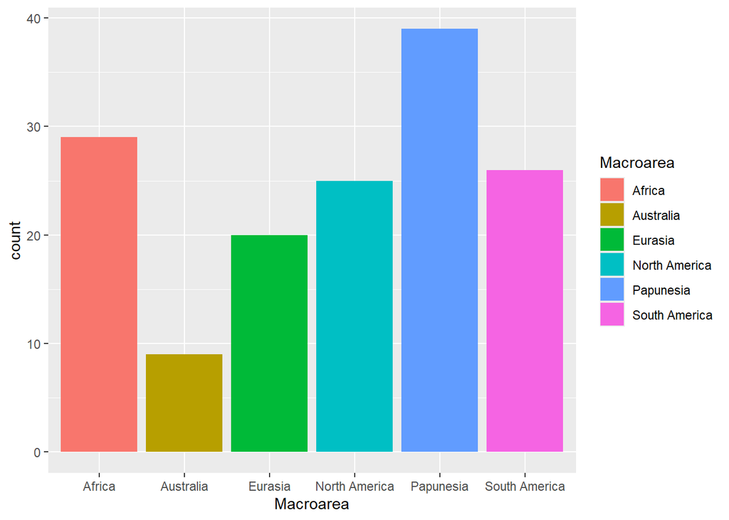

```r
ggplot(data=grammars) +
  geom_bar(aes(x=Macroarea, fill=Macroarea))
```

Препроцессинг для года написания грамматики. Необходимо трансформировать не подходящие под числовой формат данные следующим образом:

1992 [1930] -> 1992

1933-1938 -> 1938

no date -> NA

```r
preprocess_year <- function(year_string) {
  year_string <- str_remove(year_string, "\\s*\\[.*?\\]")

  if (grepl("-", year_string)) {
    year_string <- str_split(year_string, "-")[[1]][2]
  }
  year_numeric <- as.numeric(year_string)

  return(year_numeric)
}

grammars$Year <- sapply(grammars$Year, preprocess_year)
```

Выборка охватывает 120 лет лингвистических исследований. Грамматик, написанных до 1960 года, в выборке меньше всего. На графике можно наблюдать рост количества грамматик с 1980 года по настоящее время. Большинство грамматик были написаны в XXI веке:

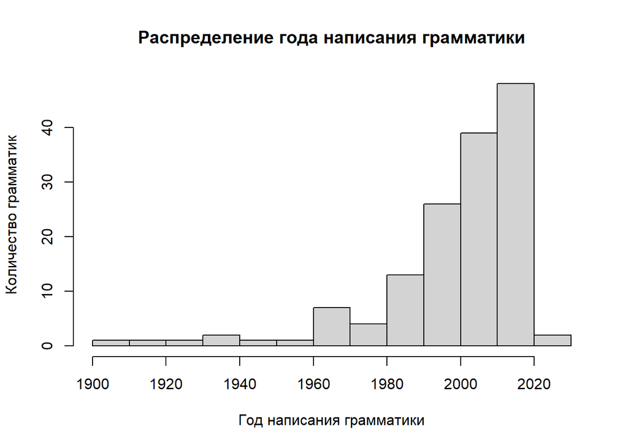

```r
hist(
  grammars$Year,
  main=paste("Распределение года написания грамматики"),
  xlab="Год написания грамматики",
  ylab="Количество грамматик"
)
```

На графике плотности распределения года грамматики по макроареалам мы можем наблюдать, что пик (самая высокая плотность) для количества грамматик находится в XXI веке для всех макроареалов, кроме Австралии, у которой пик приходится на ~1990. Самый поздний пик (~2015) у грамматик языков Африки.

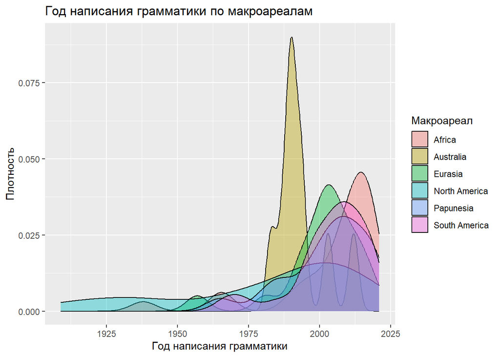

```r
ggplot(data=grammars, aes(x=Year, group=Macroarea, fill=Macroarea)) +
    geom_density(alpha=0.4) +
    labs(
      x="Год написания грамматики",
      y="Плотность",
      fill="Макроареал",
      title="Год написания грамматики по макроареалам"
    )
```

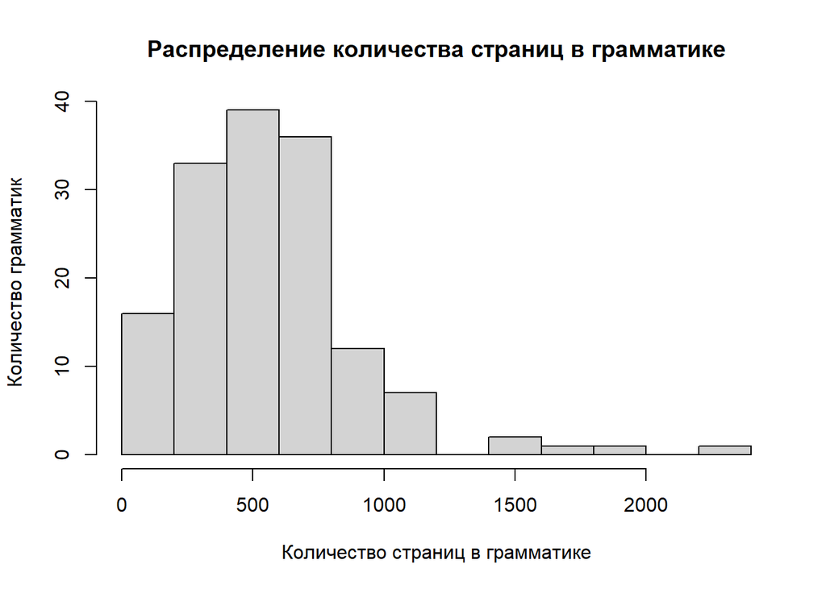

```r
hist(
  grammars$Pages,
  main=paste("Распределение количества страниц в грамматике"),
  xlab="Количество страниц в грамматике",
  ylab="Количество грамматик"
)
```

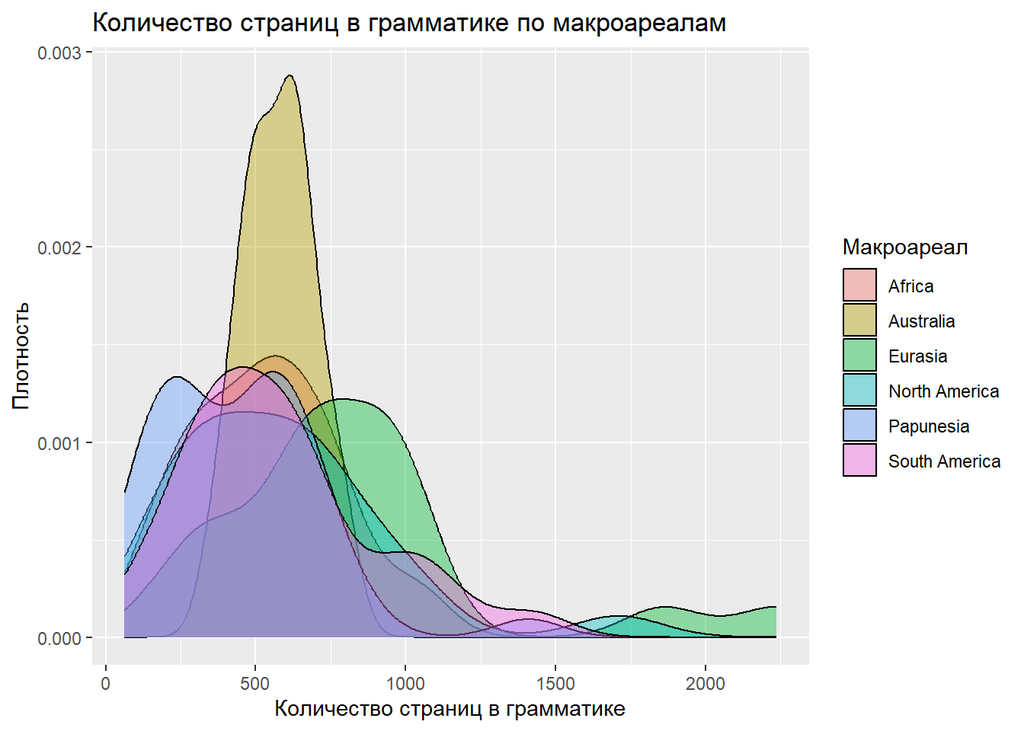

```r
ggplot(data=grammars, aes(x=Pages, group=Macroarea, fill=Macroarea)) +
    geom_density(alpha=0.4) +
    labs(
      x="Количество страниц в грамматике",
      y="Плотность",
      fill="Макроареал",
      title="Количество страниц в грамматике по макроареалам"
    )
```

Между годом написания грамматики и количеством страниц не наблюдается сильной линейной зависимости, поэтому мы учитываем оба этих предиктора при построении итоговой модели (иначе потребовалось бы удалить один из них, чтобы устранить коллинеарность).

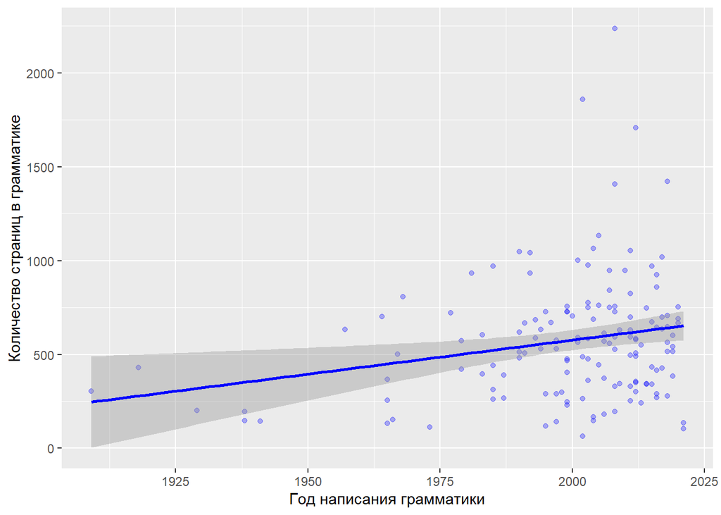

```r
ggplot(data=grammars, aes(x=Year, y=Pages)) +
  geom_point(alpha=0.3, colour="blue") +
  geom_smooth(method="lm", formula= y~x, colour="blue") +
  xlab("Год написания грамматики") +
  ylab("Количество страниц в грамматике")
```

## Подготовка данных для модели

Полный датасет с результатами предсказаний GPT-4o:

```r
rag_results <- read.csv("https://raw.githubusercontent.com/al-the-eigenvalue/from-MTEB-to-MTOB/refs/heads/main/from_mteb_to_mtob.csv")
rag_results$Year <- sapply(rag_results$Year, preprocess_year)
glimpse(rag_results)
```

```
## Rows: 5,328
## Columns: 18
## $ ISO.639.3 <chr> "spp", "djm", "mhi", "dba", "guk", "khq", "sif", "tms", "knw…
## $ Language  <chr> "Supyire", "Jamsay", "Ma'di", "Bangime", "Gumuz", "Koyra Chi…
## $ Filename  <chr> "carlson1994grammar", "heath2008grammar", "blackings2003gram…
## $ WALS.116A <chr> "Clause-initial question particle", "Clause-final question p…
## $ GB.107    <int> 1, 1, 0, 1, 1, 0, 0, 1, 1, 0, 1, 1, 1, 0, 1, 1, 1, 0, 1, 1, …
## $ WALS.81A  <chr> "SOV", "SOV", "No dominant order", "No dominant order", "SVO…
## $ Title     <chr> "A Grammar of Supyire", "A grammar of Jamsay", "A Grammar of…
## $ Family    <chr> "Niger-Congo", "Dogon", "Central Sudanic", "Bangime", "Gumuz…
## $ Subfamily <chr> "", "", "", "", "", "", "", "", "", "", "", "Benue-Congo", "…
## $ Genus     <chr> "Senufo", "Dogon", "Moru-Ma'di", "Bangime", "Gumuz", "Songha…
## $ Macroarea <chr> "Africa", "Africa", "Africa", "Africa", "Africa", "Africa", …
## $ Author    <chr> "Carlson, Robert", "Heath, Jeffrey", "Blackings, Mairi and F…
## $ Year      <dbl> 1990, 2008, 2003, 2013, 2012, 1999, 2015, 2009, 2015, 2016, …
## $ Pages     <int> 1048, 755, 750, 550, 506, 467, 432, 344, 342, 289, 134, 1019…
## $ Reranker  <int> 0, 0, 0, 0, 0, 0, 0, 0, 0, 0, 0, 0, 0, 0, 0, 0, 0, 0, 0, 0, …
## $ CoT       <int> 0, 0, 0, 0, 0, 0, 0, 0, 0, 0, 0, 0, 0, 0, 0, 0, 0, 0, 0, 0, …
## $ Feature   <chr> "WALS 81A", "WALS 81A", "WALS 81A", "WALS 81A", "WALS 81A", …
## $ Result    <int> 1, 1, 0, 1, 1, 1, 1, 1, 1, 0, 1, 1, 1, 0, 1, 1, 1, 0, 0, 1, …
```

В датасете с результатами RAG 5328 строк. это исходный датасет грамматик, размноженный в 36 раз:

- 9 лингвистических характеристик (1 для порядка слов + 1 для стратегии маркирования отрицания + 7 стратегий маркирования полярных вопросов) для каждой грамматики
- 4 конфигурации RAG (± реранкер, ± Chain-of-Thought) для каждой комбинации грамматики и характеристики.

Для построения модели потребуются следующие столбцы датасета:

- **ISO.639.3**: код языка ISO 639 как уникальный идентификатор грамматики. Он необходим для того, чтобы учитывать влияние индивидуальной грамматики как случайный эффект;
- **Feature**: лингвистическая характеристика. Она также будет рассмотрена как случайный эффект: мы взяли 9 характеристик не как фиксированный набор, а как сэмпл из всех существующих в WALS и Grambank;
- **Macroarea**: макроареал языка;
- **Year**: год публикации грамматики;
- **Pages**: количество страниц в грамматике;
- **Reranker**: 1, если в конфигурации использовался реранкер, и 0, если не использовался;
- **CoT**: 1, если в промпте для GPT-4o использовался метод цепочки рассуждений (Chain-of-Thought), и 0, если не использовался;
- **Result**: таргет-переменная. 1, если GPT-4o предсказала значение лингвистической характеристики правильно, и 0, если неправильно.

Макроареал, лингвистическая характеристика и код языка ISO 639 - категориальные переменные, поэтому их необходимо преобразовать в факторы:

```r
rag_results$ISO.639.3 <- factor(rag_results$ISO.639.3)
rag_results$Feature <- factor(rag_results$Feature)
rag_results$Macroarea <- factor(rag_results$Macroarea)
```

Во всех остальных столбцах, кроме ISO.639.3, Feature и Macroarea, находятся числовые данные. Все числовые переменные бинарные, кроме года публикации грамматики и количества страниц, поэтому необходимо нормализовать только столбцы Year и Pages:

```r
rag_results$Year_Scaled <- scale(rag_results$Year)
rag_results$Pages_Scaled <- scale(rag_results$Pages)
```

## Модель

Так как предикторов больше двух, а таргет-переменная бинарная, в качестве модели выбираем бинарную логистическую регрессию.

Так как ISO.639.3 не вложена в Feature, и Feature не вложена в ISO.639.3 (для каждого языка есть все характеристики, и для каждой характеристики есть все языки), случайные эффекты в модели будут представлены как (1 | ISO.639.3) + (1 | Feature). (источник: https://stats.stackexchange.com/questions/228800/crossed-vs-nested-random-effects-how-do-they-differ-and-how-are-they-specified)

Кроме влияния наличия/отсутствия реранкера и наличия/отсутствия Chain-of-Thought на результат по отдельности, проанализируем также и взаимодействие между ними. Все вместе можно записать как `Reranker + CoT + Reranker:CoT` или `Reranker*CoT` (источник: https://stackoverflow.com/questions/40567421/asterisk-vs-colon-in-r-formulas)

```r
model <- glmer(
  Result ~ Reranker + CoT + Reranker:CoT + Year_Scaled + Pages_Scaled + Macroarea + (1 | ISO.639.3) + (1 | Feature),
  data=rag_results,
  family=binomial,
  control=glmerControl(optimizer="bobyqa")
)
```

Summary модели:

```r
summary(model)
```

```
## Generalized linear mixed model fit by maximum likelihood (Laplace
##   Approximation) [glmerMod]
##  Family: binomial  ( logit )
## Formula: Result ~ Reranker + CoT + Reranker:CoT + Year_Scaled + Pages_Scaled +
##     Macroarea + (1 | ISO.639.3) + (1 | Feature)
##    Data: rag_results
## Control: glmerControl(optimizer = "bobyqa")
##
##      AIC      BIC   logLik deviance df.resid
##   4054.7   4140.1  -2014.4   4028.7     5243
##
## Scaled residuals:
##     Min      1Q  Median      3Q     Max
## -7.5081  0.1220  0.2739  0.4536  1.4657
##
## Random effects:
##  Groups    Name        Variance Std.Dev.
##  ISO.639.3 (Intercept) 0.8061   0.8978
##  Feature   (Intercept) 1.2643   1.1244
## Number of obs: 5256, groups:  ISO.639.3, 146; Feature, 9
##
## Fixed effects:
##                        Estimate Std. Error z value Pr(>|z|)
## (Intercept)             1.96254    0.42997   4.564 5.01e-06 ***
## Reranker                0.12897    0.11180   1.154   0.2487
## CoT                     0.22396    0.11311   1.980   0.0477 *
## Year_Scaled             0.21205    0.09716   2.183   0.0291 *
## Pages_Scaled           -0.21229    0.09771  -2.173   0.0298 *
## MacroareaAustralia     -0.48030    0.38889  -1.235   0.2168
## MacroareaEurasia        0.40368    0.32451   1.244   0.2135
## MacroareaNorth America  0.22227    0.30970   0.718   0.4730
## MacroareaPapunesia      0.21559    0.25953   0.831   0.4062
## MacroareaSouth America -0.13355    0.28027  -0.477   0.6337
## Reranker:CoT           -0.05119    0.16180  -0.316   0.7517
## ---
## Signif. codes:  0 '***' 0.001 '**' 0.01 '*' 0.05 '.' 0.1 ' ' 1
##
## Correlation of Fixed Effects:
##             (Intr) Rernkr CoT    Yr_Scl Pgs_Sc McrrAs McrrEr McrrNA McrrPp
## Reranker    -0.125
## CoT         -0.123  0.481
## Year_Scaled -0.062  0.001  0.002
## Pages_Scald  0.042 -0.001 -0.002 -0.301
## MacrorAstrl -0.236 -0.001 -0.001  0.139 -0.074
## MacroareErs -0.282  0.001  0.001  0.137 -0.323  0.324
## McrrNrthAmr -0.306  0.000  0.001  0.375 -0.172  0.366  0.441
## MacroarPpns -0.333  0.000  0.001 -0.006  0.070  0.367  0.423  0.459
## McrrSthAmrc -0.314  0.000 -0.001  0.024 -0.068  0.349  0.433  0.444  0.510
## Reranker:CT  0.087 -0.691 -0.699  0.000  0.000  0.000  0.000  0.000  0.000
##             McrrSA
## Reranker
## CoT
## Year_Scaled
## Pages_Scald
## MacrorAstrl
## MacroareErs
## McrrNrthAmr
## MacroarPpns
## McrrSthAmrc
## Reranker:CT  0.000
```

## Анализ и интерпретация

### Фиксированные эффекты

**CoT (Chain-of-Thought):** β = 0.22396, p-value = 0.0477. β > 0, и это означает, что использование Chain-of-Thought увеличивает вероятность правильного ответа. Наличие/отсутствие Chain-of-Thought статистически значимо (p-value = 0.0477). β = 0.22396 соответствует увеличению log-odds в 0.22396, т.е. odds в exp(0.22396) ≈ 1.25 раз (на 25%).

источник для интерпретации β: https://www.sthda.com/english/articles/36-classification-methods-essentials/151-logistic-regression-essentials-in-r/

**Reranker:** Эффект незначим (β = 0.12897, p-value = 0.2487). Использование реранкера само по себе не приводит к значимому улучшению результатов.

**Взаимодействие Reranker и CoT:** Эффект незначим (β = -0.05119, p-value = 0.7517) => совместное использование реранкера и CoT не дает дополнительного эффекта сверх того, что ожидается от простого сложения их индивидуальных эффектов.

**Год издания:** Положительный значимый эффект (β = 0.21205, p-value = 0.0291). Более новые книги ассоциированы с увеличением вероятности правильного ответа. Так как переменная масштабирована: при увеличении года издания на одно стандартное отклонение log-odds правильного ответа увеличивается на 0.21205 (odds увеличивается в exp(0.21205) ≈ на 24%).

(scale трансформирует данные так, чтобы среднее было 0, а стандартное отклонение было 1 https://www.rdocumentation.org/packages/base/versions/3.6.2/topics/scale, поэтому увеличение значения нормализованного предиктора на 1 = увеличение значения предиктора на одно стандартное отклонение)

**Макроареал:** Ни один из макроареалов не показал статистически значимого эффекта по сравнению с бейзлайном (Африка, так как она не указана в summary модели). Все p-значения > 0.05. Это означает, что макроареал языка не влияет на эффективность модели.

### Случайные эффекты

**ISO.639.3:** Дисперсия = 0.806 (т.к. стандартное отклонение = 0.898, дисперсия = 0.898^2). Указывает на то, что между языками существуют различия в сложности или в качестве описания в грамматике, которые влияют на результат.

**Лингвистическая характеристика:** Дисперсия = 1.264 (т.к. стандартное отклонение = 1.1244). Значительная вариация между вопросами, что ожидаемо — некоторые вопросы сложнее других.

### Выводы

- Лучшая конфигурация: Chain-of-Thought (использование реранкера не значимо).
- Грамматики: лучше результат для новых и с меньшим количеством страниц.
- Макроареал не имеет значения.
- Учет случайных эффектов (язык и лингвистическая характеристика) важен, так как они вносят существенную изменчивость.

### Post-hoc тест для конфигураций RAG

Для попарного сравнения конфигураций RAG используем post-hoc тест TukeyHSD:

```r
config_emmeans <- emmeans(
  model,
  ~ Reranker * CoT,
  at=list(Reranker=c(0, 1), CoT=c(0, 1))
)

pairs(config_emmeans, adjust="tukey")
```

```
##  contrast                        estimate    SE  df z.ratio p.value
##  Reranker0 CoT0 - Reranker1 CoT0  -0.1290 0.112 Inf  -1.154  0.6562
##  Reranker0 CoT0 - Reranker0 CoT1  -0.2240 0.113 Inf  -1.980  0.1955
##  Reranker0 CoT0 - Reranker1 CoT1  -0.3017 0.114 Inf  -2.641  0.0412
##  Reranker1 CoT0 - Reranker0 CoT1  -0.0950 0.115 Inf  -0.829  0.8408
##  Reranker1 CoT0 - Reranker1 CoT1  -0.1728 0.116 Inf  -1.493  0.4419
##  Reranker0 CoT1 - Reranker1 CoT1  -0.0778 0.117 Inf  -0.665  0.9103
##
## Results are averaged over the levels of: Macroarea
## Results are given on the log odds ratio (not the response) scale.
## P value adjustment: tukey method for comparing a family of 4 estimates
```

Единственное статистически значимое различие обнаружено между бейзлайном (Reranker = 0, CoT = 0) и той конфигурацией, где используются и реранкер, и Chain-of-Thought: p-value = 0.0412.

Для Reranker = 0 CoT = 1 статистически значимого различия с бейзлайном не оказалось (p-value = 0.1955), несмотря на то, что в самой модели CoT был статистически значимым с p-value = 0.0477.

Возможная интерпретация:

Самый оптимальный вариант - использовать при предсказании лингвистических характеристик по грамматикам и Chain-of-Thought, и реранкер. При ограниченных вычислительных ресурсах использовать только Chain-of-Thought.